# Simulation of an Exponential Distribution and the Central Limit Theorem

Manuel A. Cerda R.

31 de July de 2016

# Overview

This simulation investigates the exponential distribution in R and compares it with the Central Limit Theorem. The exponential distribution is simulated in R wirh rexp(n, lambda) where lambda is the rate parameter. The mean of exponential distribution is 1/lambda and the standard deviation is also 1/lambda where lambda = 0.2 for all of the simulations. The distribution of averages is based upon 40 exponentials. And, a total of a 1000 simulations are considered.

### Content

1. Simulations
2. Sample Mean versus Theoretical Mean
3. Sample Variance versus Theoretical Variance
4. Distributions

### Simulations

```r
# setting the random generator seed to ensure replicable steps
set.seed(1234);

# declaring known variables
lambda <- 0.2
t_mean <- 1/lambda
n <- 40
n_sim <- 1000

# generating n=40 random exponentials
my_rexp <- function() { rexp(n, rate = lambda) }
summary(my_rexp())
```

```
##     Min.  1st Qu.   Median     Mean  3rd Qu.     Max.
##  0.01997  1.16700  3.93700  4.96900  8.11200 21.62000
```

```r
# generating the 1000 simulated trials
simTrials <- data.frame(values=replicate(n_sim, mean(my_rexp() )))
summary(simTrials$values)
```

```
##    Min. 1st Qu.  Median    Mean 3rd Qu.    Max.
##   3.170   4.428   4.937   4.974   5.505   7.390
```

```r
# calculating cumputable variables
s_mean <- mean(simTrials$values)
t_sd <- t_mean * 1 / sqrt(n)
s_sd <- sd(simTrials$values)
s_var <- var(simTrials$values)
t_var <- t_sd^2
```

### Sample Mean versus Theoretical Mean

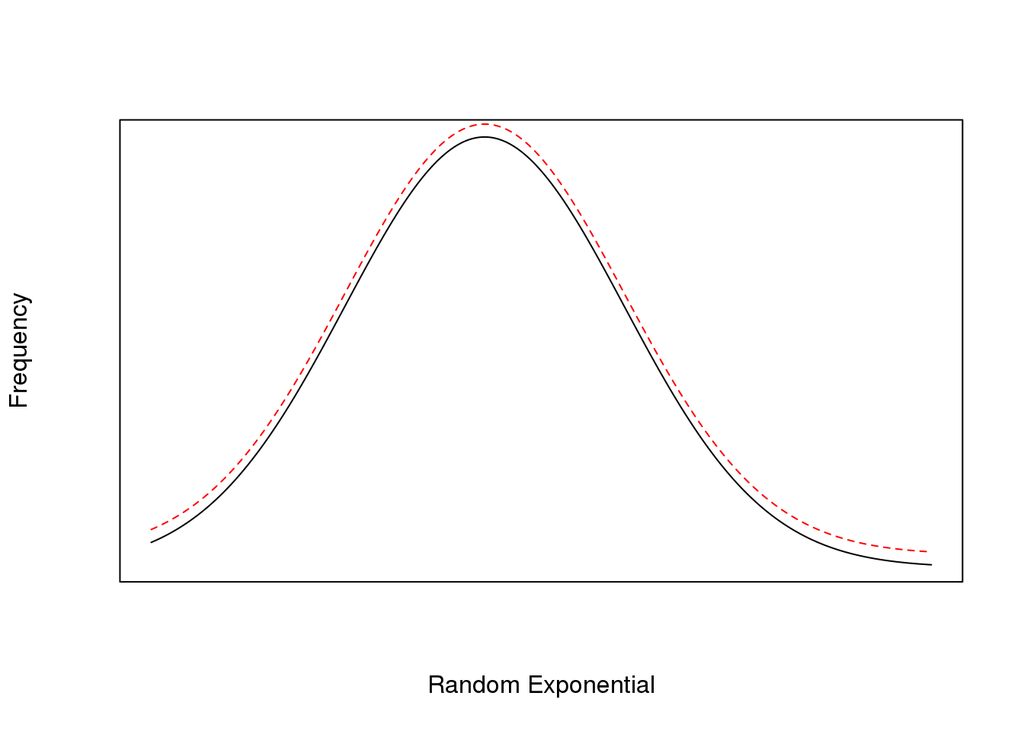

```r
# Normal Exponential Distribution
xfit <- seq(min(simTrials$values), max(simTrials$values), length = n_sim)
yfit <- dnorm(xfit, mean = s_mean, sd = s_sd)

plot(xfit, yfit*50, lty=1, type="l", ylab= "Frequency", xlab="Random Exponential", main="", xaxt='n', yaxt='n')

lines(xfit, yfit*50 + t_sd, lty=2, col ="red")
```

The Sample Mean is close enough to the Theoretical Mean.

### Sample Variance versus Theoretical Variance

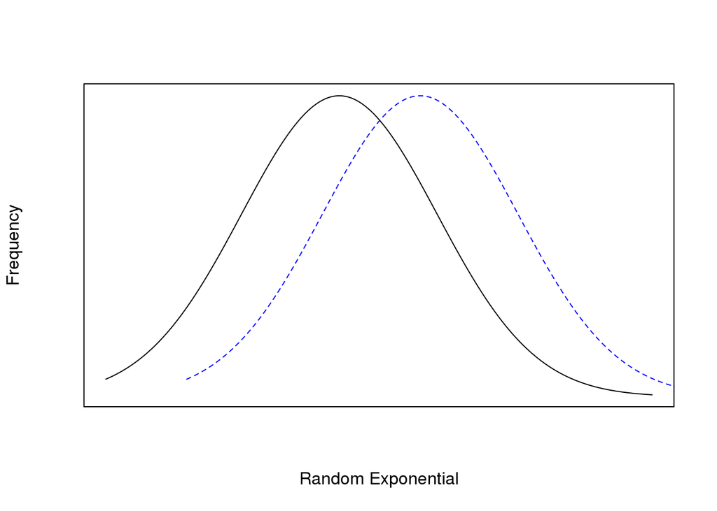

```r
# Normal Exponential Distribution
plot(xfit, yfit*10, lty=1, type="l", ylab= "Frequency", xlab="Random Exponential", main="", xaxt='n', yaxt='n')

lines(xfit + t_var, yfit*10, lty=2, col ="blue")
```

### Distributions

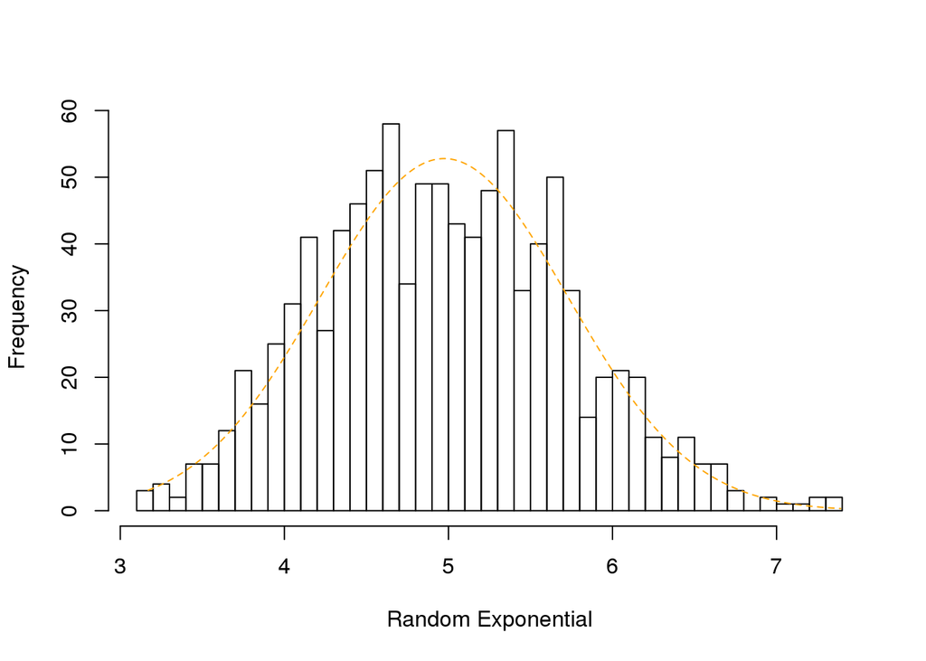

```r
# Normal Exponential Distribution
h <- hist(simTrials$values, breaks =n, freq= T, ylab= "Frequency", xlab="Random Exponential", main="", col=rgb(1, 1, 1, 0.25))

lines(xfit , yfit * 100, lty=2, col ="orange")
```

It makes sense to say that simulating a thousand trials makes the results get closer to a normal distribution. Also, with this behaviours, It’s demonstrated the Central Limit Theorem where the population has a mean and all of its values are centered around the mean.